# Let’s get functional

## Today

Today, we are going to cover two important topics: 1. Using a “functional programming” approach to make your code more efficient and avoid “repeating yourself”—copying and pasting essentially the same code over and over again 2. As part of the functional programming approach, how to write your own functions in R to do useful things.

```r
library(tidyverse)
library(correlation)
bfi <- psychTools::bfi
keys <- replace_na(psychTools::bfi.dictionary$Keying, 1)

bfi_mean <- bfi %>%
  mutate(across(names(bfi)[keys == -1], ~ 7 - .x)) %>%
  rowwise() %>%
  mutate(A = mean(c_across(A1:A5), na.rm = TRUE),
         C = mean(c_across(C1:C5), na.rm = TRUE),
         E = mean(c_across(E1:E5), na.rm = TRUE),
         N = mean(c_across(N1:N5), na.rm = TRUE),
         O = mean(c_across(O1:O5), na.rm = TRUE)
  ) %>%
  ungroup() %>%
  mutate(
    gender = recode_factor(gender, `1` = "male", `2` = "female"),
    education = recode_factor(
      education,
      `1` = "some hs",
      `2` = "hs",
      `3` = "some college",
      `4` = "college",
      `5` = "graduate degree")
  ) %>%
  select(gender:O)

descriptives_men <- bfi_mean %>%
  filter(gender == "male") %>%
  summarize(across(A:O, list(mean = mean, sd = sd), na.rm = TRUE)) %>%
  pivot_longer(cols = everything(), names_to = c("scale", ".value"), names_sep = "_")

corr_men <- bfi_mean %>%
  filter(gender == "male") %>%
  correlation::correlation(select = c("A", "C", "E", "N", "O")) %>%
  summary()

tab_men <- full_join(
  descriptives_men,
  corr_men,
  by = c("scale" = "Parameter")
)

descriptives_women <- bfi_mean %>%
  filter(gender == "female") %>%
  summarize(across(A:O, list(mean = mean, sd = sd), na.rm = TRUE)) %>%
  pivot_longer(cols = everything(), names_to = c("scale", ".value"), names_sep = "_")

corr_women <- bfi_mean %>%
  filter(gender == "female") %>%
  correlation::correlation(select = c("A", "C", "E", "N", "O")) %>%
  summary()

tab_women <- full_join(
  descriptives_women,
  corr_women,
  by = c("scale" = "Parameter")
)
```

Note, you might also try out the *apaTables* package:

```r
bfi_mean %>%
  filter(gender == "female") %>%
  select(A:O) %>%
  apaTables::apa.cor.table()
```

This works, but it can get really tedious. What if you wanted to do this sort of analysis with the five educational levels? Or with a factor with 25 levels?

Similarly, what if we wanted to fit the same regression model (e.g., to estimate gender differences) for 5 or 25 oOr 100 variables? What if you wanted to fit a bunch of similar, but slightly different, versions of the model (e.g., regressing on gender, age, education, or a combination of these)?

These sorts of repetitive tasks are a recipe for boredom and finger cramps at best and typos or errors at worst (potentially with big consequences if you don’t catch them before they are disseminated).

Functional programming can come to the rescue here. The idea of functional programming is that, rather than writing bespoke code for each new analysis or each new variable, we can **write the code once** and then **apply it over and over again** as needed for new analyses.

Let’s rewrite the above code as a function. What is happening in each part of this code?

```r
descriptives_men <- bfi_mean %>%
  filter(gender == "male") %>%
  summarize(across(A:O, list(mean = mean, sd = sd), na.rm = TRUE)) %>%
  pivot_longer(cols = everything(), names_to = c("scale", ".value"), names_sep = "_")

corr_men <- bfi_mean %>%
  filter(gender == "male") %>%
  correlation::correlation(select = c("A", "C", "E", "N", "O")) %>%
  summary()

tab_men <- full_join(
  descriptives_men,
  corr_men,
  by = c("scale" = "Parameter")
)
```

In this block we are:

1. Taking a data set, then
2. Computing the descriptives table, then
3. Computing the correlation matrix, then
4. Merging the two tables together, then
5. Returning the combined table.

Let’s translate the code into something more generic by writing a **function**!

## Writing a function

To write a function in R, use the following template:

```r
function_name <- function(arguments) {
  # function code
}
```

```r
function_name <- function(arg1, arg2, arg3 = FALSE) {
  # function steps go here
  return(result)
}
```

A function as three parts:

1. Its **name**: how do we call it?
2. Its **arguments**: what are its inputs?
3. Its **body**: what does it do with the inputs?

First, pick a name for your function. Like all of your object names, make your function names clear and unambiguous. `my_awesome_function()` doesn’t tell us anything about what the function does. Usually, I prefer to make my function names *verbs* to make it clear that they *do* something.

Then, tell R that you are making a function by assigning `function() {}` to your function name:

```r
function_name <- function() {}
```

Your arguments go *inside the parentheses* after `function`. Follow the same basic guidelines for naming arguments as you do for naming any object in R. Give your arguments understandable names and be consistent in your naming scheme.

To give an argument a default value, specify the default with `=`. For example, this function will take a vector of numbers and draw a histogram of them, with the default color being blue:

```r
plot_histogram <- function(data, color = "blue") {
  tbl <- tibble(data = data)
  ggplot(tbl, aes(x = data)) +
  geom_histogram(color = color, fill = color)
}
```

If the user of this function doesn’t specify a color, the line and fill colors will be blue:

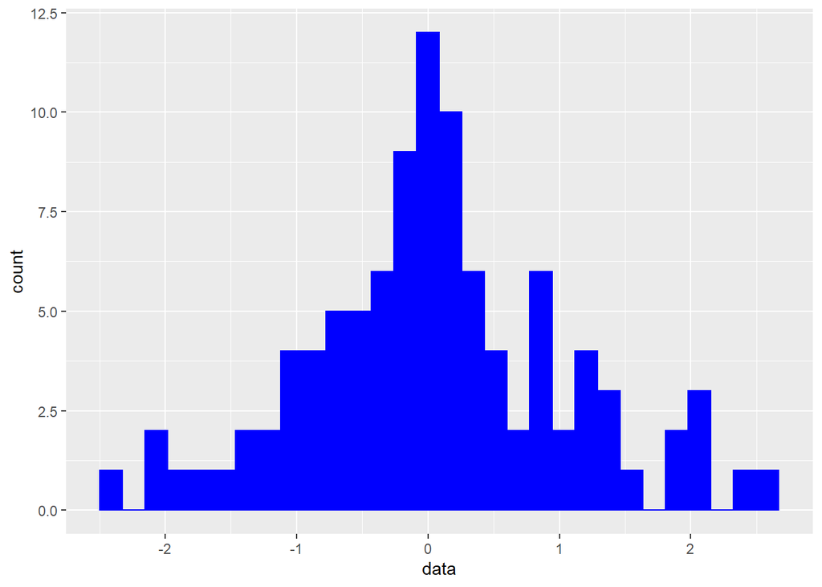

```r
simulated_data <- rnorm(100)
plot_histogram(simulated_data)
```

If the user of the function *does* specify a color, the line and fill colors will be the specified color:

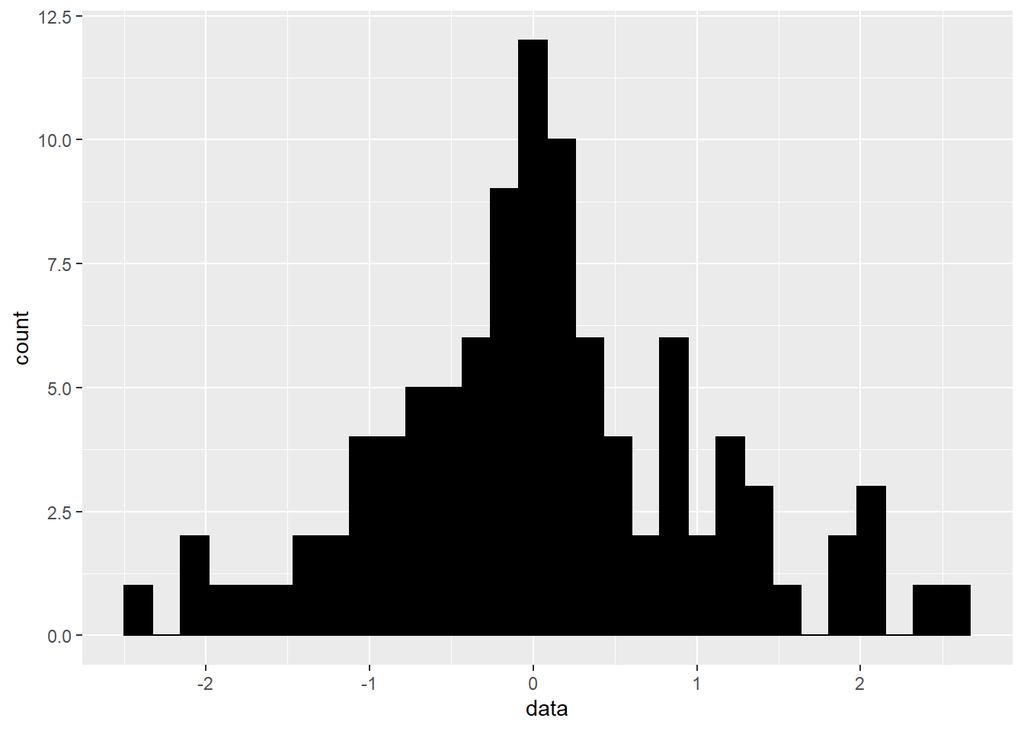

```r
plot_histogram(simulated_data, color = "black")
```

For more guidance on writing R functions, including advanced features and testing, see Chapter 19 of [R for Data Science](https://r4ds.had.co.nz/functions.html).

For a great video overview of good functional design, see [this keynote](https://www.youtube.com/watch?v=Qne86lxjgtg).

## Writing a descriptives table function

Let’s turn the descriptives table code into a function!

```r
descriptives_men <- bfi_mean %>%
  filter(gender == "male") %>%
  summarize(across(A:O, list(mean = mean, sd = sd), na.rm = TRUE)) %>%
  pivot_longer(cols = everything(), names_to = c("scale", ".value"), names_sep = "_")

corr_men <- bfi_mean %>%
  filter(gender == "male") %>%
  correlation::correlation(select = c("A", "C", "E", "N", "O")) %>%
  summary()

tab_men <- full_join(
  descriptives_men,
  corr_men,
  by = c("scale" = "Parameter")
)
```

In this block we are:

1. Taking a data set, then
2. Computing the descriptives table, then
3. Computing the correlation matrix, then
4. Merging the two tables together, then
5. Returning the combined table.

```r
make_table_1 <- function(.data, variables) {
  descriptives <- .data %>%
    summarize(across(all_of(variables), list(mean = mean, sd = sd), na.rm = TRUE)) %>%
    pivot_longer(cols = everything(), names_to = c("scale", ".value"), names_sep = "_")

  corr <- .data %>%
    correlation::correlation(select = variables) %>%
    summary()

  tab <- full_join(
    descriptives,
    corr,
    by = c("scale" = "Parameter")
  )

  return(tab)
}

bfi_men <- filter(bfi_mean, gender == "male")
bfi_women <- filter(bfi_mean, gender == "female")
big_five <- c("A", "C", "E", "N", "O")

tab_men <- make_table_1(bfi_men, variables = big_five)
tab_men
```

```
## # A tibble: 5 x 7
##   scale  mean    sd       O      N      E      C
##   <chr> <dbl> <dbl>   <dbl>  <dbl>  <dbl>  <dbl>
## 1 A      4.39 0.929  0.137   0.177  0.487  0.242
## 2 C      4.14 0.967  0.201   0.268  0.294 NA
## 3 E      3.99 1.12   0.169   0.232 NA     NA
## 4 N      4.05 1.14   0.0879 NA     NA     NA
## 5 O      4.65 0.814 NA      NA     NA     NA
```

```r
tab_women <- make_table_1(bfi_women, variables = big_five)
tab_women
```

```
## # A tibble: 5 x 7
##   scale  mean    sd       O      N      E      C
##   <chr> <dbl> <dbl>   <dbl>  <dbl>  <dbl>  <dbl>
## 1 A      4.78 0.853  0.178   0.238  0.431  0.247
## 2 C      4.33 0.938  0.202   0.238  0.235 NA
## 3 E      4.22 1.02   0.251   0.239 NA     NA
## 4 N      3.73 1.21   0.0755 NA     NA     NA
## 5 O      4.55 0.804 NA      NA     NA     NA
```

## Now you try!

**Individual `bfi` Reports**

Select 10 people from the `bfi` dataset. Prepare an individualized report for each person presenting the following information:

1. Their mean score on each of the Big Five scales.
2. The percentile of their mean score compared to the rest of the full sample of 2800 people (hint: use the `quantile()` function).
3. A profile plot illustrating their level on each Big Five trait. - For examples, see [here](https://www.unzcloud.com/wp-content/uploads/2014/02/teddypersonality.png) or [here](https://projects.fivethirtyeight.com/personality-quiz/).
4. Bonus: In addition, provide individualized *narrative* descriptions of what each of their scores means (e.g., based on whether they are “high”, “medium”, or “low” on each trait). See the two examples linked above for ideas

To save yourself a bunch of tedious report writing, write a function to do this!

```r
ind_bfi <- function(.dat){
  sample_mean <- .dat %>%
    slice_head(n = 10) %>%
    summarize(across(c(A, C, N, E, O),(mean = mean), na.rm = TRUE))

  full_mean <- .dat %>%
    summarize(across(c(A, C, N, E, O),(mean = mean), na.rm = TRUE))

  f <- ecdf(full_mean)
  f(sample_mean)

  return(c(sample_mean, full_mean, f(sample_mean)))
}
```